# Kalman Filter Localization

## Timothy Devon Morris

### Kalman Filter

Kalman filtering, also known as linear quadratic estimation (LQE), is an algorithm that uses a series of measurements observed over time, containing statistical noise and other inaccuracies, and produces estimates of unknown variables that tend to be more accurate than those based on a single measurement alone, by using Bayesian inference and estimating a joint probability distribution over the variables for each timeframe. The filter is named after Rudolf E. Kálmán, one of the primary developers of its theory.

The basic algorithm takes a mean $\mu_{t-1}$, a covariance $\Sigma_{t-1}$, and a control $u_t$ and updates your belief based on some measurement $z_t$. We also have zero-mean normally distributed process noise with covariance $Q_t$, and zero-mean normally distributed sensor noise with covariance $R_t$. Assuming that we have a linear motion model (i.e. $x_t = Ax_{t-1} + Bu_t$), we update our belief in the following way.

#### Predict

$\bar{\mu}_t = A_tu_{t-1} + B_tu_t$

$\bar{\Sigma}_t = A_t\Sigma_{t-1}A_t^T + Q_t$

#### Measurement update

$K_t = \bar{\Sigma}_tC_t^T(C_t\bar{\Sigma}_tC_t^T + R_t)^{-1}$

$\mu_t = \bar{\mu}_t + K_t(z_t - C_t\bar{\mu}_t)$

$\Sigma_t = (I - K_tC_t)\bar{\Sigma}_t$

```python
import numpy as np
import numpy.linalg as la
import matplotlib.pyplot as plt
import scipy.io as sio

class KF(object):
    '''
    Class to implement a Kalman Filter for a linear-gaussian system
    '''

    def __init__(self,A,B,C,Q,R):
        '''
        Class Variables:
        A - numpy matrix (nxn) state transition matrix
        B - numpy matrix (nxk) control matrix
        C - numpy matrix (mxn) measurement matrix
        Q - numpy matrix (nxn) process noise covariance
        R - numpy matrix (mxm) sensor noise covariance
        '''
        self.A = A
        self.B = B
        self.C = C
        self.Q = Q
        self.R = R

    def filter(self,Z,U,x0=0):
        '''
        Filters over a fixed number of time steps

        Inputs:
        Z - numpy matrix (mxT) measurements for T time steps
        U - numpy matrix (kxT) controls for T time steps
        x0 - numpy matrix (nx1) initial guess of position

        Outputs:
        X - numpy array
        '''
        n,k = self.A.shape
        m,T = Z.shape
        X = np.zeros((n,T+1))
        X = np.matrix(X)

        pos_Cov = np.zeros(T)
        K_gain = np.zeros(T)

        X[:,0] = x0
        Cov = 10*self.Q
        for t, u in enumerate(U.T):
            # Prediction
            mu = self.A*X[:,t] + self.B*u
            Cov = self.A*Cov*self.A.T + self.Q

            # Measurement Update
            K = Cov*self.C.T*(la.inv(self.C.dot(Cov).dot(C.T) + self.R))
            mu += K*(Z[:,t] - self.C*mu)
            Cov = (np.eye(n) - K*(self.C))*Cov
            X[:, t+1] = mu
            pos_Cov[t] = Cov[0,0]
            K_gain[t] = K[0,0]

        return X, pos_Cov, K_gain
```

### Autonomous Underwater Vehicles (AUV)

The Kalman Filter can be used to estimate the states of an Autonomous Underwater Vehicle (AUV). The continuous time dynamics are given by

$ \dot{x} = v$

$ \dot{v} = -\frac{b}{m}v + \frac{F(t)}{m} $

and we are assuming in this case that

$ F(t) = \begin{cases} 50N & 0 \leq t < 5 \\ -50N & 25 \leq t < 30 \\ 0N & \text{otherwise} \end{cases} $

We will assume that we get a measurement of position as our output and that we have a noise covariances of

$ R = .001$

We can convert this to discrete time state space form

$x_{t+1} = Ax_t + Bu_{t+1}$

$z_{t} = Cx_t$

if we let

$ A = \begin{bmatrix} 1 & \Delta t \\ 0 & 1 - \frac{b\Delta t}{m} \end{bmatrix} $

$ B = \begin{bmatrix} 0 \\ \frac{\Delta t}{m} \end{bmatrix} $

$ C = \begin{bmatrix} 1 & 0 \\ \end{bmatrix} $

$ Q_d = \Delta t^2 Q_c$

Note: This is a first order euler approximation, but since $\Delta t$ is small enough, it should be sufficient.

```python
b = 20 # drag coeff N*s/m
m = 100 # mass in kg
delT = .05 # timestep in seconds

# Initialize the matrices for linear model
A = np.matrix([[1., delT],
              [0., 1 - b*delT/m]])

B = np.matrix([[0.],
             [delT/m]])
C = np.matrix([[1., 0.]])

# Initialize noise covariances
Q = np.matrix([[.0001, 0.],
              [0, .01]])

Q = delT**2*Q

R = np.matrix([[.001]])

# Initialize Kalman Filter
kf = KF(A,B,C,Q,R)

# Initialize the control
T = np.arange(0,50.05, delT)
U = np.zeros_like(T)
U[T < 5] = 50
U[T >= 25] = -50
U[T >= 30] = 0

# Simulate some data
X = np.zeros((A.shape[0],U.shape[0]+1))
X = np.matrix(X)
X[0,0] = 5
Z = np.zeros((C.shape[0],U.shape[0]+1))
Z = np.matrix(Z)
for i, u in enumerate(U.T):
    X[:,i+1] = A*X[:,i] + B*u + np.matrix(np.random.multivariate_normal(np.zeros(2), cov=Q)).T
    Z[:,i+1] = C*X[:,i+1] + np.random.normal(loc = 0, scale=np.sqrt(R))

X_hat, pos_Cov, K_gain = kf.filter(Z,U)
```

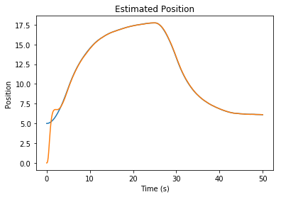

```python
plt.plot(T, X[0,:-1].T)
plt.plot(T, X_hat[0,:-2].T)
plt.xlabel('Time (s)')
plt.ylabel('Position')
plt.title("Estimated Position")
plt.show()
```

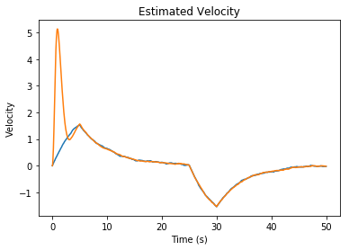

```python
plt.plot(T, X[1,:-1].T)
plt.plot(T, X_hat[1,:-2].T)
plt.xlabel('Time (s)')
plt.ylabel('Velocity')
plt.title("Estimated Velocity")
plt.show()
```

We can see from these plots, that even with a very bad initial guess, the estimator converges very quickly in position. It also converges quickly in velocity, but due to the higher noise on velocity, the estimate is not exact.

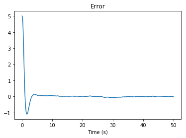

```python
plt.plot(T, X[0,:-1].T - X_hat[0,:-2].T)
plt.xlabel('Time (s)')
plt.title("Error")
plt.show()
```

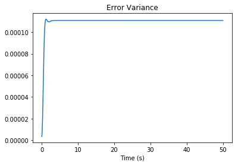

```python
plt.plot(T, pos_Cov[:-1])
plt.xlabel('Time (s)')
plt.title("Error Variance")
plt.show()
```

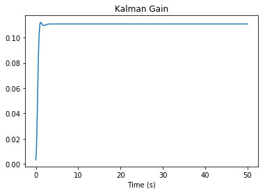

```python
plt.plot(T, K_gain[:-1])
plt.xlabel('Time (s)')
plt.title("Kalman Gain")
plt.show()
```

### Questions

• Does your estimator work as expected?

Since the system is linear, the estimator converges very, very quickly

• How does the covariance change between the prediction and measurement update?

The covariance shrinks between the prediciton and measurement update

• Do your gains have any interesting transient characteristics? How does increasing the measurement noise affect your Kalman gains? Decreasing the measurement noise?

### Data Given by Dr. McLain

```python
mat_contents = sio.loadmat('hw1_soln_data.mat')
```

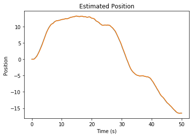

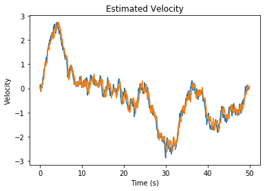

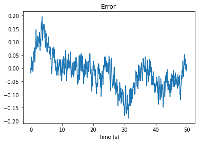

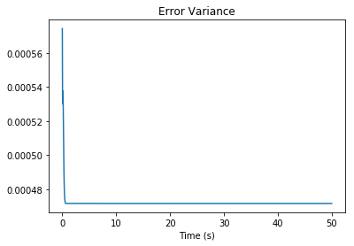

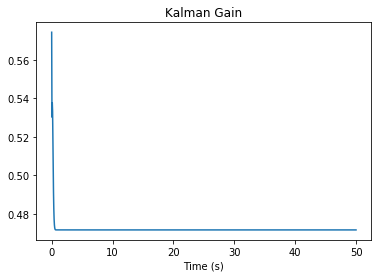

```python
b = 20 # drag coeff N*s/m
m = 100 # mass in kg
delT = .05 # timestep in seconds

# Initialize the matrices for linear model
A = np.matrix([[1., delT],
              [0., 1 - b*delT/m]])

B = np.matrix([[0.],
             [delT/m]])
C = np.matrix([[1., 0.]])

# Initialize noise covariances
Q = np.matrix([[.0001, 0.],
              [0, .01]])

#Q = delT**2*Q

R = np.matrix([[.001]])

# Initialize Kalman Filter
kf = KF(A,B,C,Q,R)

# Initialize the control
T = np.arange(0,50.05, delT)
U = np.zeros_like(T)
U[T < 5] = 50
U[T >= 25] = -50
U[T >= 30] = 0

xtr = mat_contents['xtr']
vtr = mat_contents['vtr']
Z = np.matrix(mat_contents['z'])
U = np.matrix(mat_contents['u'])


X_hat, pos_Cov, K_gain = kf.filter(Z,U)

plt.plot(T, xtr.T)
plt.plot(T, X_hat[0,:-1].T)
plt.xlabel('Time (s)')
plt.ylabel('Position')
plt.title("Estimated Position")
plt.show()

plt.plot(T, vtr.T)
plt.plot(T, X_hat[1,:-1].T)
plt.xlabel('Time (s)')
plt.ylabel('Velocity')
plt.title("Estimated Velocity")
plt.show()

plt.plot(T, (xtr - X_hat[0,:-1]).T)
plt.xlabel('Time (s)')
plt.title("Error")
plt.show()

plt.plot(T, pos_Cov[:])
plt.xlabel('Time (s)')
plt.title("Error Variance")
plt.show()

plt.plot(T, K_gain[:])
plt.xlabel('Time (s)')
plt.title("Kalman Gain")
plt.show()
```